# Data Structure and Characterization

This notebook is designed to check for general structure of all relevant datasets, distribution of observations, and shared naming conventions.

# Key questions for Valerie:

- What are the distinctions between different species (WAPS/annuals/natives/weeds)?
- In particular, what is “other”? What is a “weed”?
- What is the definition of “fall clipping”
- Is there a “low fert”?
- Does the distribution of observations seem correct?

# Ways to think about this dataset:

- Differences in temporal priority
- Single group treatments are used to give temporal priority
- Multi-group treatments remove priority for one or more groups
- Interactions with other treatment effects
- How does priority among groups differ with treatment effects
- Note - only present for a subset of all group treatments

# Reading in all relevant datasets:

To add - resin data, when finished.

# Variables:

- H2O
  - Control - No water added
  - Dry - Decrease water 25% Sept-Feb, 35% March-April
  - Wet - Increase water 25% Sept-April, 50% of all other times, add 3 weeks of rain at the end of season
  - Late wet - No change Sep-April, 50% of all other times, add 3 weeks of rain at the end of season
  - Added later in the experiment? (Sarah)
  - Control-2nd - No water added, less maintained for species composition (see notes)
- Fertilization
  - None
  - High fert - high fert = 45 kg N/ha/yr (4.5 g/m2/yr) spread out over 3 applications (early- mid- Nov, mid-Jan, early-March)
- Clipping
  - None
  - Fall clipping - ??
  - Spring clipping - 2 clips mid-march through mid-april

# How many observations are there for each unique treatment combination?

```r
relevant_trts = c("annuals", "WAPS", "Natives", "natives+WAPS+annuals", "annuals+natives", "WAPS+annuals", "WAPS+natives")

checklabels = checklabels[checklabels$Sp.comp %in% relevant_trts,]

table(checklabels %>% select(one_of("H2O", "Sp.comp", "Fertilization", "Clipping")))
```

```
## , , Fertilization = highfert, Clipping = fallclipping
##
##              Sp.comp
## H2O           annuals annuals+natives Natives natives+WAPS+annuals WAPS
##   control           0               0       0                    8    0
##   control-2nd       0               0       0                    7    0
##   dry               0               0       0                    3    0
##   latewet           0               0       0                    3    0
##   wet               0               0       0                    3    0
##              Sp.comp
## H2O           WAPS+annuals WAPS+natives
##   control                8            0
##   control-2nd            7            0
##   dry                    3            0
##   latewet                3            0
##   wet                    3            0
##
## , , Fertilization = none, Clipping = fallclipping
##
##              Sp.comp
## H2O           annuals annuals+natives Natives natives+WAPS+annuals WAPS
##   control           8               0       0                    8    8
##   control-2nd       7               0       0                    7    0
##   dry               3               0       0                    3    0
##   latewet           3               0       0                    3    0
##   wet               3               0       0                    3    0
##              Sp.comp
## H2O           WAPS+annuals WAPS+natives
##   control                8            0
##   control-2nd            7            0
##   dry                    3            0
##   latewet                3            0
##   wet                    3            0
##
## , , Fertilization = highfert, Clipping = none
##
##              Sp.comp
## H2O           annuals annuals+natives Natives natives+WAPS+annuals WAPS
##   control           0               0       0                    8    0
##   control-2nd       0               0       0                    7    0
```

[output cut: 46 more lines]

```
##
##              Sp.comp
## H2O           annuals annuals+natives Natives natives+WAPS+annuals WAPS
##   control           8               0       0                    8    8
##   control-2nd       7               0       0                    7    3
##   dry               3               0       0                    3    0
##   latewet           3               0       0                    3    3
##   wet               3               0       0                    3    2
##              Sp.comp
## H2O           WAPS+annuals WAPS+natives
##   control                8            0
##   control-2nd            7            0
##   dry                    3            0
##   latewet                3            0
##   wet                    3            0
```

# How many total observations (plot x year) are there for each unique treatment combination in the cover dataset?

```r
relevant_trts = c("annuals", "WAPS", "Natives", "natives+WAPS+annuals", "annuals+natives", "WAPS+annuals", "WAPS+natives")

group_percents = group_percents[cover$sp.trt %in% relevant_trts,]
cover = cover[cover$sp.trt %in% relevant_trts,]

cover %>%
  group_by(sp.trt) %>%
  filter(h2o != "control-2nd") %>%
  summarise(count = n()) %>%
  arrange(desc(count))
```

| sp.trt | count |
| --- | --- |
| natives+WAPS+annuals | 1020 |
| WAPS+annuals | 1020 |
| annuals | 510 |
| WAPS | 380 |
| annuals+natives | 170 |
| Natives | 170 |
| WAPS+natives | 170 |

# Do cover data labels line up with data checking labels?

```r
library(testthat)
```

```r
for(rowindex in 1:nrow(cover)){

  plotno = cover$plot[rowindex]

  # Is water the same?
  expect_equivalent(cover$h2o[rowindex], checklabels$H2O[checklabels$Plot.. == plotno])

  # Is fertilizer the same?
  expect_equivalent(cover$fertilization[rowindex], checklabels$Fertilization[checklabels$Plot.. == plotno])

  # Is clipping the same?
  expect_equivalent(cover$clip[rowindex], checklabels$Clipping[checklabels$Plot.. == plotno])

}

head(cover)
```

|  | X | plot | block | subblock | precip.block | h2o | other.treatment | sp.trt | fertilization | clip | year | aegilops | ag.big | ag.small | amsinckia | avena | big.leaf.dandelion | bindweed | bro.carinatus | bro.hordeaceous | bro.madritensis | bro.diandrus | bunchgrass | cap.bur | centaurea | con.arv | conyza | elymus | epilobium.brach | … |
| --- | --- | --- | --- | --- | --- | --- | --- | --- | --- | --- | --- | --- | --- | --- | --- | --- | --- | --- | --- | --- | --- | --- | --- | --- | --- | --- | --- | --- | --- | --- |
| 1 | 1 | 1 | 1 | 1 | A | latewet | 35 | annuals | none | springclipping | 2008 | 0 | 0 | 0 | 0 | 12.5 | 0 | 0 | 0 | 2.5 | 0 | 0 | 0 | 0 | 0 | 0 | 0 | 0 | 0 | … |
| 2 | 2 | 1 | 1 | 1 | A | latewet | 35 | annuals | none | springclipping | 2009 | 0 | 0 | 0 | 0 | 12.5 | 0 | 0 | 0 | 2.5 | 0 | 0 | 0 | 0 | 0 | 0 | 0 | 0 | 0 | … |
| 3 | 3 | 1 | 1 | 1 | A | latewet | 35 | annuals | none | springclipping | 2010 | 0 | 0 | 0 | 0 | 25.0 | 0 | 0 | 0 | 0.0 | 0 | 0 | 0 | 0 | 0 | 0 | 0 | 0 | 0 | … |
| 4 | 4 | 1 | 1 | 1 | A | latewet | 35 | annuals | none | springclipping | 2011 | 0 | 0 | 0 | 0 | 75.0 | 0 | 0 | 0 | 0.0 | 0 | 0 | 0 | 0 | 0 | 0 | 0 | 0 | 0 | … |
| 5 | 5 | 1 | 1 | 1 | A | latewet | 35 | annuals | none | springclipping | 2012 | 0 | 0 | 0 | 0 | 35.0 | 0 | 0 | 0 | 0.0 | 0 | 0 | 0 | 0 | 0 | 0 | 0 | 0 | 0 | … |
| 6 | 6 | 1 | 1 | 1 | A | latewet | 35 | annuals | none | springclipping | 2013 | 0 | 0 | 0 | 0 | 25.0 | 0 | 0 | 0 | 0.0 | 0 | 0 | 0 | 0 | 0 | 0 | 0 | 0 | 0 | … |

# Do group (class) totals equal those supplied on the general data summary?

```r
calc_class_percent <- function(x){

  sums = c()
  count = 1

  for(g in unique(waps.specs$group)){
    sums[count] = sum(x[,colnames(x) %in% waps.specs$specname[waps.specs$group == g]])
    count = count + 1
  }

  names(sums) =  unique(waps.specs$group)

  return(data.frame(t(sums)))
}

class_percent <- cover %>% group_by(plot, year) %>% do(calc_class_percent(.))

diff_ann <- c();diff_nat<- c();diff_waps<- c(); diff_weeds<- c()

for(rowindex in 1:nrow(class_percent)){

  diff_ann[rowindex] = class_percent$annual[rowindex] - group_percents$annuals[rowindex]
  diff_nat[rowindex] = class_percent$natives[rowindex] - group_percents$natives[rowindex]
  diff_waps[rowindex] = class_percent$waps[rowindex] - group_percents$waps[rowindex]
  diff_weeds[rowindex] = class_percent$weeds[rowindex] - group_percents$weeds[rowindex]

}

group_diffs = data.frame(diff_ann, diff_nat, diff_waps, diff_weeds)
```

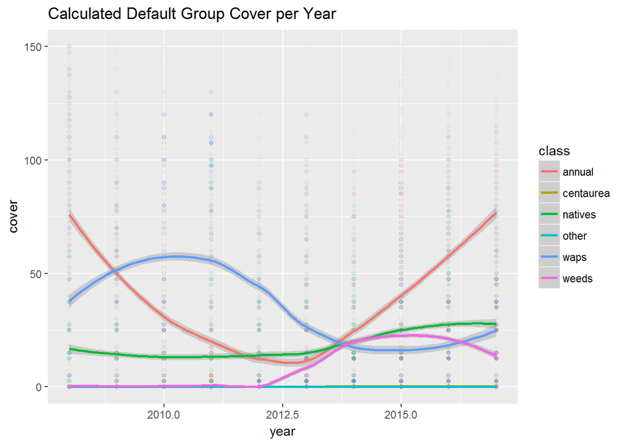

```r
library(ggplot2)

gather(class_percent, key = "class", value = "cover", -c(plot, year)) %>%
  ggplot(aes(x = year,
      y = cover,
      color = class)) +
  geom_point(alpha = .01) +
  stat_smooth(method = "loess") +
  ylim(0, 150) +
  ggtitle("Calculated Default Group Cover per Year")
```

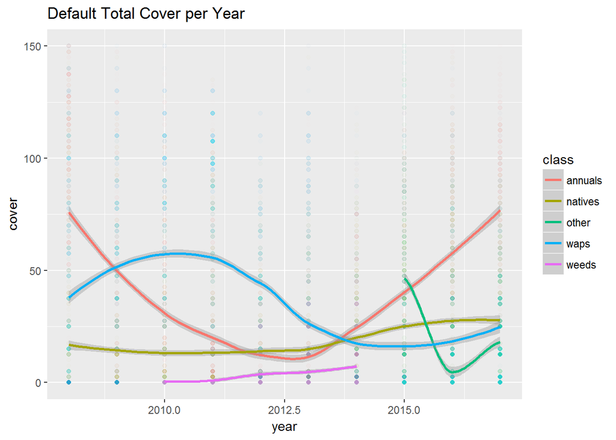

```r
gather(bind_cols(class_percent[,1:2], group_percents[,colnames(group_percents) %in% c("annuals", "natives", "waps", "weeds", "other")]),
       key = "class", value = "cover", -c(plot, year)) %>%
  ggplot(aes(x = year,
      y = cover,
      color = class)) +
  geom_point(alpha = .01) +
  stat_smooth(method = "loess") +
  ylim(0, 150) +
  ggtitle("Default Total Cover per Year")
```

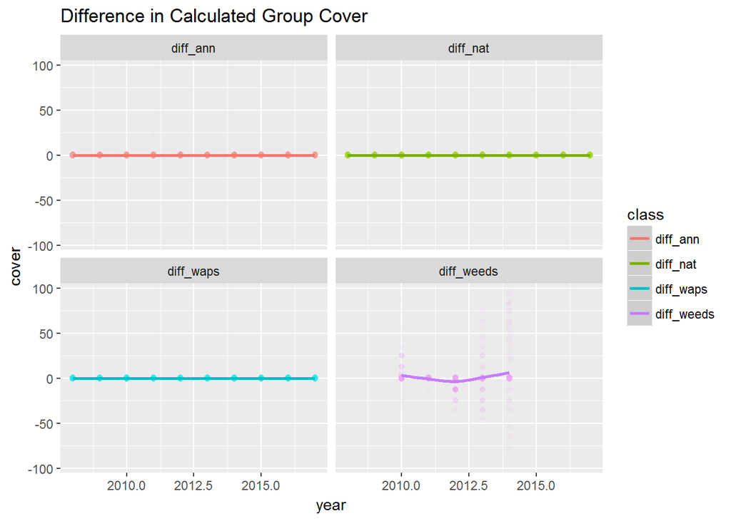

```r
data.frame(bind_cols(class_percent[,1:2], group_diffs)) %>%
  gather(key = "class", value = "cover", -c(plot, year), convert = TRUE) %>%
  ggplot(aes(x = year,
      y = cover,
      color = class)) +
  geom_jitter(alpha = .01, width = .01, height = 1) +
  stat_smooth(method = "loess") +
  facet_wrap(~class) +
  ggtitle("Difference in Calculated Group Cover")
```